[output not shown]

# WineQualityReds Analysis by Jasonbai

```
##  fixed.acidity   volatile.acidity  citric.acid    residual.sugar
##  Min.   : 4.60   Min.   :0.1200   Min.   :0.000   Min.   : 0.900
##  1st Qu.: 7.10   1st Qu.:0.3900   1st Qu.:0.090   1st Qu.: 1.900
##  Median : 7.90   Median :0.5200   Median :0.260   Median : 2.200
##  Mean   : 8.32   Mean   :0.5278   Mean   :0.271   Mean   : 2.539
##  3rd Qu.: 9.20   3rd Qu.:0.6400   3rd Qu.:0.420   3rd Qu.: 2.600
##  Max.   :15.90   Max.   :1.5800   Max.   :1.000   Max.   :15.500
##
##    chlorides       free.sulfur.dioxide total.sulfur.dioxide
##  Min.   :0.01200   Min.   : 1.00       Min.   :  6.00
##  1st Qu.:0.07000   1st Qu.: 7.00       1st Qu.: 22.00
##  Median :0.07900   Median :14.00       Median : 38.00
##  Mean   :0.08747   Mean   :15.87       Mean   : 46.43
##  3rd Qu.:0.09000   3rd Qu.:21.00       3rd Qu.: 62.00
##  Max.   :0.61100   Max.   :72.00       Max.   :289.00
##                                        NA's   :2
##     density             pH          sulphates         alcohol
##  Min.   :0.9901   Min.   :2.740   Min.   :0.3300   Min.   : 8.40
##  1st Qu.:0.9956   1st Qu.:3.210   1st Qu.:0.5500   1st Qu.: 9.50
##  Median :0.9968   Median :3.310   Median :0.6200   Median :10.20
##  Mean   :0.9967   Mean   :3.311   Mean   :0.6581   Mean   :10.42
##  3rd Qu.:0.9978   3rd Qu.:3.400   3rd Qu.:0.7300   3rd Qu.:11.10
##  Max.   :1.0037   Max.   :4.010   Max.   :2.0000   Max.   :14.90
##
##     quality
##  Min.   :3.000
##  1st Qu.:5.000
##  Median :6.000
##  Mean   :5.636
##  3rd Qu.:6.000
##  Max.   :8.000
##
```

### 1.structure of dataset 数据说明

Title: Wine Quality ,This dataset is public available for research.

> P. Cortez, A. Cerdeira, F. Almeida, T. Matos and J. Reis. Modeling wine preferences by data mining from physicochemical properties. In Decision Support Systems, Elsevier, 47(4):547-553. ISSN: 0167-9236.

> Available at: [@Elsevier] http://dx.doi.org/10.1016/j.dss.2009.05.016 [Pre-press (pdf)] http://www3.dsi.uminho.pt/pcortez/winequality09.pdf [bib] http://www3.dsi.uminho.pt/pcortez/dss09.bib

Created by: Paulo Cortez (Univ. Minho), Antonio Cerdeira, Fernando Almeida, Telmo Matos and Jose Reis (CVRVV) @ 2009

变量统计：共计12个变量

```
## [1] 1599   12
```

```
##  [1] "alcohol"              "chlorides"            "citric.acid"
##  [4] "density"              "fixed.acidity"        "free.sulfur.dioxide"
##  [7] "pH"                   "quality"              "residual.sugar"
## [10] "sulphates"            "total.sulfur.dioxide" "volatile.acidity"
```

#### 1.1 Attribute information: 变量值

> 1. fixed acidity (tartaric acid - g / dm^3)
> 2. volatile acidity (acetic acid - g / dm^3)
> 3. citric acid (g / dm^3)
> 4. residual sugar (g / dm^3)
> 5. chlorides (sodium chloride - g / dm^3
> 6. free sulfur dioxide (mg / dm^3)
> 7. total sulfur dioxide (mg / dm^3)
> 8. density (g / cm^3)
> 9. pH
> 10. sulphates (potassium sulphate - g / dm3)
> 11. alcohol (% by volume) Output variable (based on sensory data):
> 12. quality (score between 0 and 10)

#### 1.2 Description of attributes:变量描述

其中体现红酒的酸、甜、咸、苦的成分归纳如下：  
酸：Fixed acidity（酒石酸）、Volatile acidity（醋酸） 、 Citric acid（柠檬酸） 甜：Residual sugar（糖分） 、alcohol（酒精） 咸：chlorides（氯化钠）  
苦：Free sulfur dioxide（游离二氧化硫）、Total sulfur dioxide（总二氧化硫）、sulphates（硫酸钾）

#### 1.3 变量反思

显示的变量只是红酒主要的基本成分，并没有微量成分，由葡萄酒的品尝原理我们知道，葡萄酒中的微量成分是香气和滋味成分中最主要的部分，这些成分数目极大而浓度极小。这可能对我们的分析会造成不利的影响，即体现红酒质量的自变量缺失了，某些甚至可能是重要的变量。

#### 1.4 基础数据处理， 缺失值观察

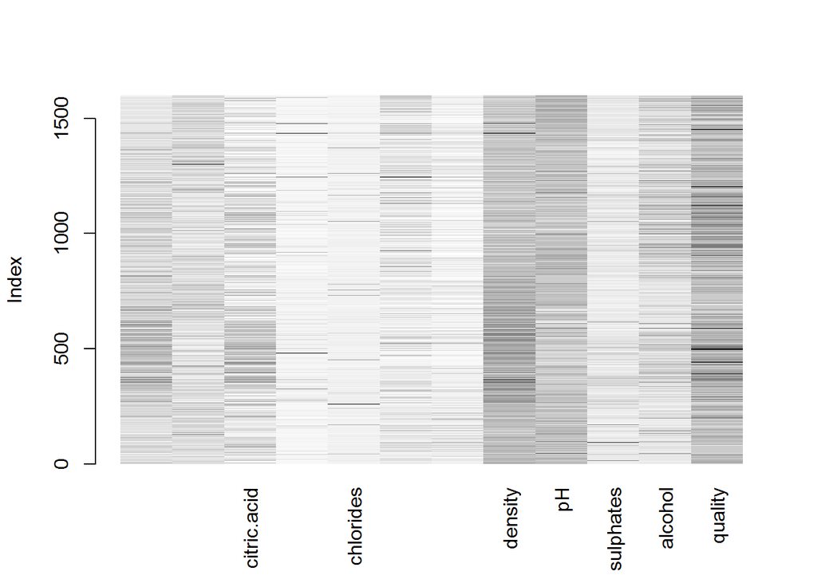

本次的数据比较规整，无需做大量的数据清洗，缺失值只有两个，做删除处理

### 2.Leading Questions

**1.**影响高品质葡萄酒的有效因素有哪些？ **2.**是什么原因导致葡萄酒的质量不合格?  
**3.**是否可以依据化学成分预测葡萄酒的质量？

### 3. 单因素分析

#### 3.1 Quality

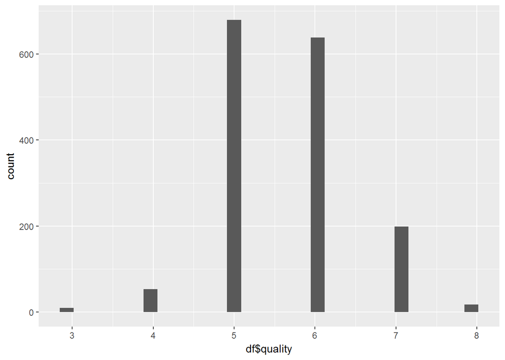

```
##    Min. 1st Qu.  Median    Mean 3rd Qu.    Max.
##   3.000   5.000   6.000   5.637   6.000   8.000
```

这批数据中，变量质量几乎是正态分布。最好的评分实际上是8，但是在直方图中占比特别少，3的评级也相当罕见。如果想要比较这些不同的群体，这些群体的规模太小可能是个问题。

```
##   Group.1 fixed.acidity volatile.acidity citric.acid residual.sugar
## 1       3          7.50            0.845       0.035            2.1
## 2       4          7.50            0.670       0.090            2.1
## 3       5          7.80            0.580       0.230            2.2
## 4       6          7.90            0.490       0.260            2.2
## 5       7          8.80            0.370       0.400            2.3
## 6       8          8.25            0.370       0.420            2.1
##   chlorides free.sulfur.dioxide total.sulfur.dioxide  density   pH
## 1    0.0905                 6.0                 15.0 0.997565 3.39
## 2    0.0800                11.0                 26.0 0.996500 3.37
## 3    0.0810                15.0                 47.0 0.997000 3.30
## 4    0.0780                14.0                 35.0 0.996560 3.32
## 5    0.0730                11.0                 27.0 0.995770 3.28
## 6    0.0705                 7.5                 21.5 0.994940 3.23
##   sulphates alcohol
## 1     0.545   9.925
## 2     0.560  10.000
## 3     0.580   9.700
## 4     0.640  10.500
## 5     0.740  11.500
## 6     0.740  12.150
```

从上图观察，还是很难区对红酒品质的好坏，有较好的区分度观察，所以我计划新建一个变量，用于归类区分品质好坏。

```
##
##         bad  medium-low      medium medium-high        good
##          63         679         638         199          18
```

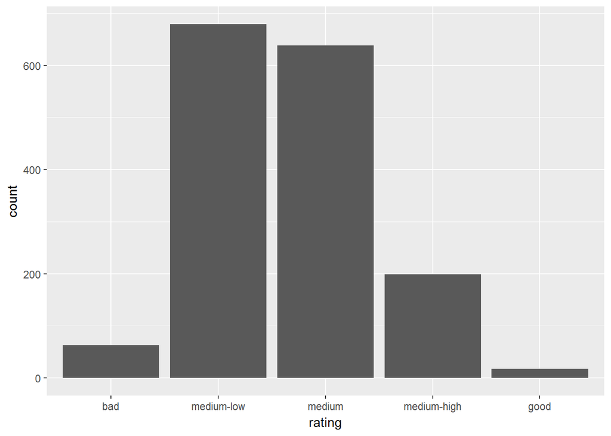

```
##       Group.1 fixed.acidity volatile.acidity citric.acid residual.sugar
## 1         bad          7.50             0.68        0.08            2.1
## 2  medium-low          7.80             0.58        0.23            2.2
## 3      medium          7.90             0.49        0.26            2.2
## 4 medium-high          8.80             0.37        0.40            2.3
## 5        good          8.25             0.37        0.42            2.1
##   chlorides free.sulfur.dioxide total.sulfur.dioxide density   pH
## 1    0.0800                 9.0                 26.0 0.99660 3.38
## 2    0.0810                15.0                 47.0 0.99700 3.30
## 3    0.0780                14.0                 35.0 0.99656 3.32
## 4    0.0730                11.0                 27.0 0.99577 3.28
## 5    0.0705                 7.5                 21.5 0.99494 3.23
##   sulphates alcohol
## 1      0.56   10.00
## 2      0.58    9.70
## 3      0.64   10.50
## 4      0.74   11.50
## 5      0.74   12.15
```

这样看起来就好多了，能明显区隔品质。

#### 3.2 接着来观察酿酒制作中几个主要变量，alcohol，residual.sugar，density

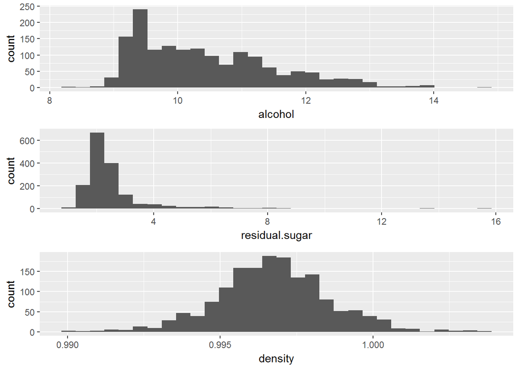

alcohol（酒精）的百分比从8到14，与高乙醇含量杀死酵母的背景知识一致，因此不能超过15%。 density（密度）大多数葡萄酒的密度低于水，因为乙醇比水密度更小。 residual.sugar （甜度）多数集中在2左右，从直方图无法得出更多的结论，因为整体数据较为集中。

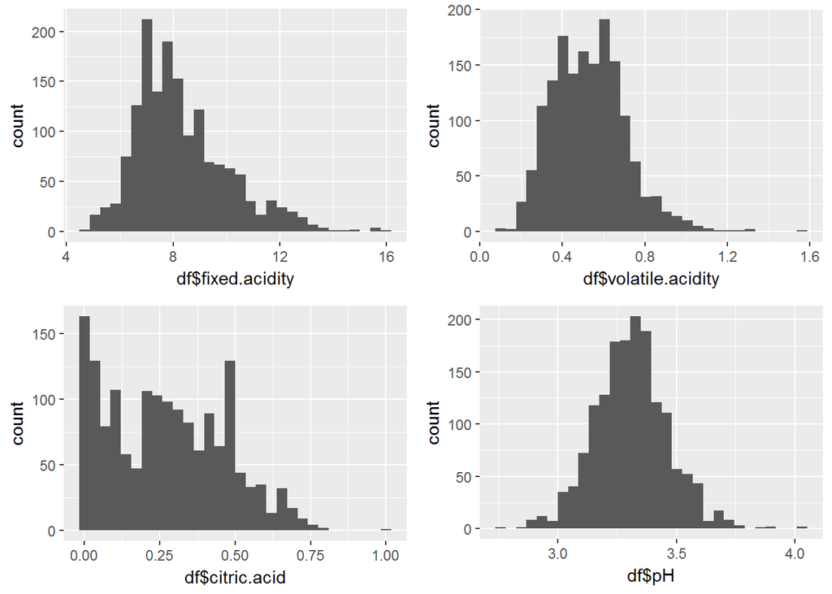

PH值，fixed.acidity，volatile.acidity三个值，符合正态分布。citric.acid为非正态分布，大多数小于0.75

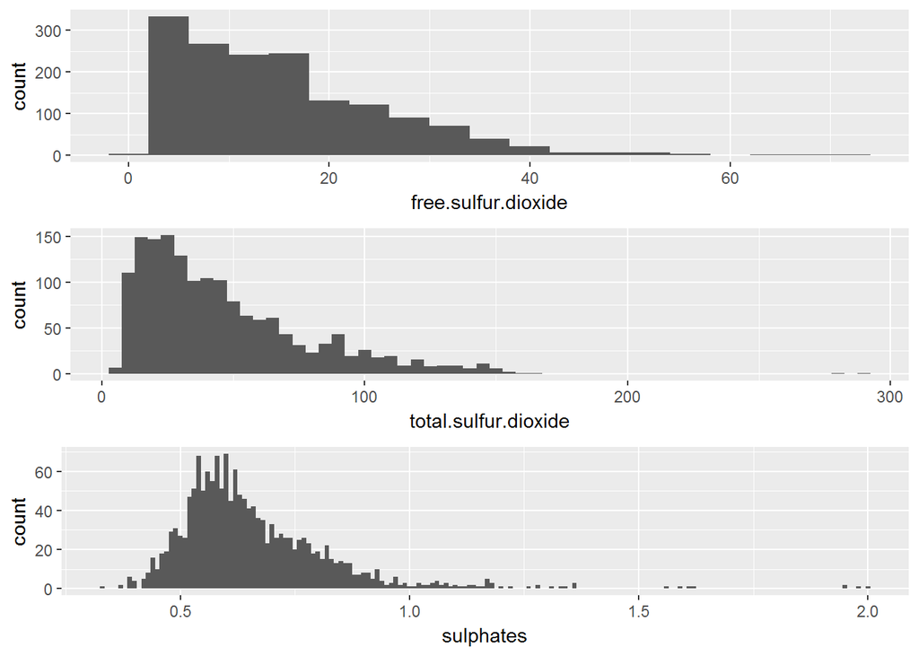

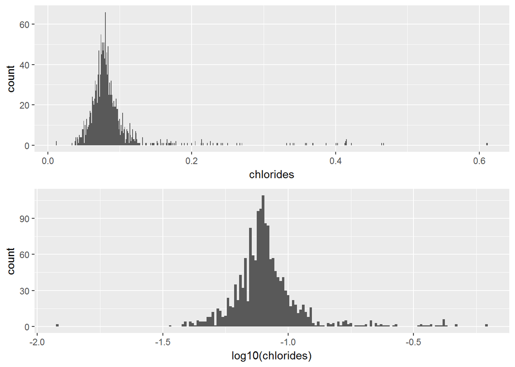

chlorides主要为集中在0.1，呈现正态分布。

### 4.Univariate Analysis

**What is the structure of your dataset?**  
1597个观察，12个变量，quality为因变量，其他为自变量，且都为数值型。 >  
其中体现红酒的酸、甜、咸、苦的成分归纳如下：  
* 酸：Fixed acidity（酒石酸）、Volatile acidity（醋酸） 、 Citric acid（柠檬酸）  
* 甜：Residual sugar（糖分） 、alcohol（酒精） * 咸：chlorides（氯化钠）  
* 苦：Free sulfur dioxide（游离二氧化硫）、Total sulfur dioxide（总二氧化硫）、sulphates（硫酸钾）

**What is/are the main feature(s) of interest in your dataset?**

在酿酒过程中，我主要感兴趣Residual sugar 和 alcohol

**What other features in the dataset do you think will help support your investigation into your feature(s) of interest?**  
volatile.acidity and free.sulfur.dioxide 是影响酒的重要因素。 除此之外还有fixed acidity,citric acidity也会影响口感;  
pH和density并不是很感兴趣。

**Did you create any new variables from existing variables in the dataset?**  
是的，我生成了一个新的变量来排除异常值及数据过于分散的影响。

### 5.Bivariate Plots Section

#### 5.1 变量间相关性观察

```
##                      fixed.acidity volatile.acidity citric.acid
## fixed.acidity           1.00000000     -0.255633041  0.67120591
## volatile.acidity       -0.25563304      1.000000000 -0.55228351
## citric.acid             0.67120591     -0.552283514  1.00000000
## residual.sugar          0.11650789      0.001025845  0.14607451
## chlorides               0.09390893      0.061226723  0.20427744
## free.sulfur.dioxide    -0.15079882     -0.012999909 -0.05558572
## total.sulfur.dioxide   -0.11214493      0.075853190  0.03724338
## density                 0.66785035      0.022478244  0.36439884
## pH                     -0.68450954      0.235576476 -0.54399501
## sulphates               0.18176867     -0.260407811  0.31130106
## alcohol                -0.06280815     -0.201804712  0.10857619
## quality                 0.12320006     -0.390225874  0.22536054
##                      residual.sugar    chlorides free.sulfur.dioxide
## fixed.acidity           0.116507890  0.093908930        -0.150798816
## volatile.acidity        0.001025845  0.061226723        -0.012999909
## citric.acid             0.146074515  0.204277438        -0.055585720
## residual.sugar          1.000000000  0.055480246         0.183270062
## chlorides               0.055480246  1.000000000         0.005103644
## free.sulfur.dioxide     0.183270062  0.005103644         1.000000000
## total.sulfur.dioxide    0.201861132  0.047288267         0.668809257
## density                 0.356685216  0.200773215        -0.019487408
## pH                     -0.084636070 -0.265008413         0.073954228
## sulphates               0.007463648  0.371796054         0.057284788
## alcohol                 0.043494157 -0.221118808        -0.066264541
## quality                 0.014984934 -0.128841725        -0.047698544
##                      total.sulfur.dioxide     density          pH
## fixed.acidity                 -0.11214493  0.66785035 -0.68450954
## volatile.acidity               0.07585319  0.02247824  0.23557648
## citric.acid                    0.03724338  0.36439884 -0.54399501
## residual.sugar                 0.20186113  0.35668522 -0.08463607
## chlorides                      0.04728827  0.20077322 -0.26500841
## free.sulfur.dioxide            0.66880926 -0.01948741  0.07395423
## total.sulfur.dioxide           1.00000000  0.07205768 -0.06570171
## density                        0.07205768  1.00000000 -0.34244998
## pH                            -0.06570171 -0.34244998  1.00000000
## sulphates                      0.04446529  0.14773016 -0.19800647
## alcohol                       -0.20484057 -0.49720344  0.20501427
## quality                       -0.18434369 -0.17563963 -0.05848341
##                         sulphates     alcohol     quality
## fixed.acidity         0.181768671 -0.06280815  0.12320006
## volatile.acidity     -0.260407811 -0.20180471 -0.39022587
## citric.acid           0.311301059  0.10857619  0.22536054
## residual.sugar        0.007463648  0.04349416  0.01498493
## chlorides             0.371796054 -0.22111881 -0.12884172
## free.sulfur.dioxide   0.057284788 -0.06626454 -0.04769854
## total.sulfur.dioxide  0.044465293 -0.20484057 -0.18434369
## density               0.147730164 -0.49720344 -0.17563963
## pH                   -0.198006469  0.20501427 -0.05848341
## sulphates             1.000000000  0.09239271  0.25051925
## alcohol               0.092392709  1.00000000  0.47572001
## quality               0.250519246  0.47572001  1.00000000
```

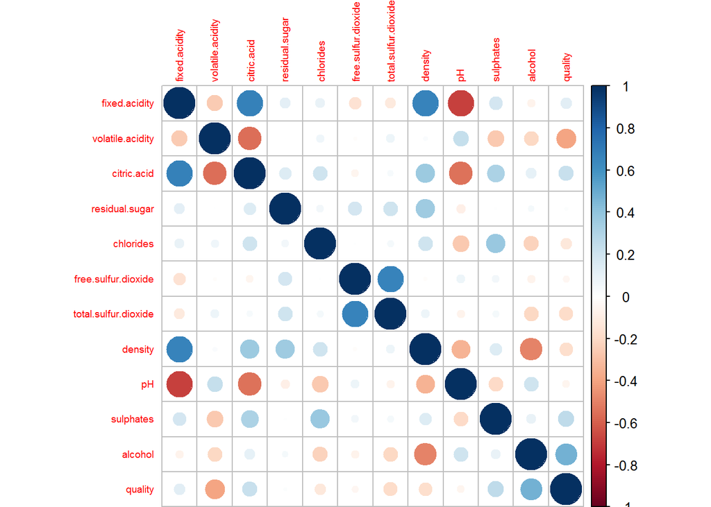

可以看到Fixed acidity与density，Citric acid、PH 的相关系数在0.68左右。 Free sulfur dioxide与total.sulfur.dioxide，的相关系数在0.68左右。

其他变量之间的相关程度并不高。其中，Fixed acidity 与PH、Volatile acidity与Fixed acidity、alcohol与density之间存在负相关性。 综上也说明了，在葡萄酒的成分里，Fixed acidity和许多化学成分存在相关性。

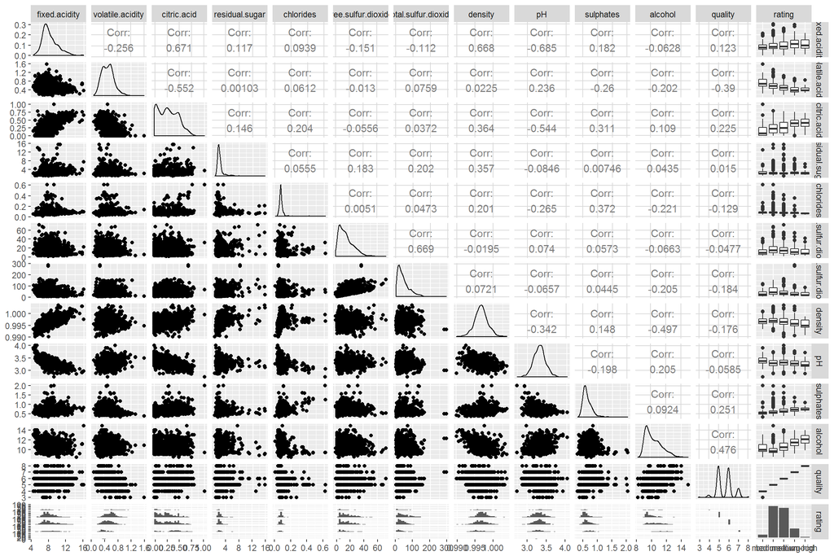

#### 5.2 Alcohol and Volatile.acidity

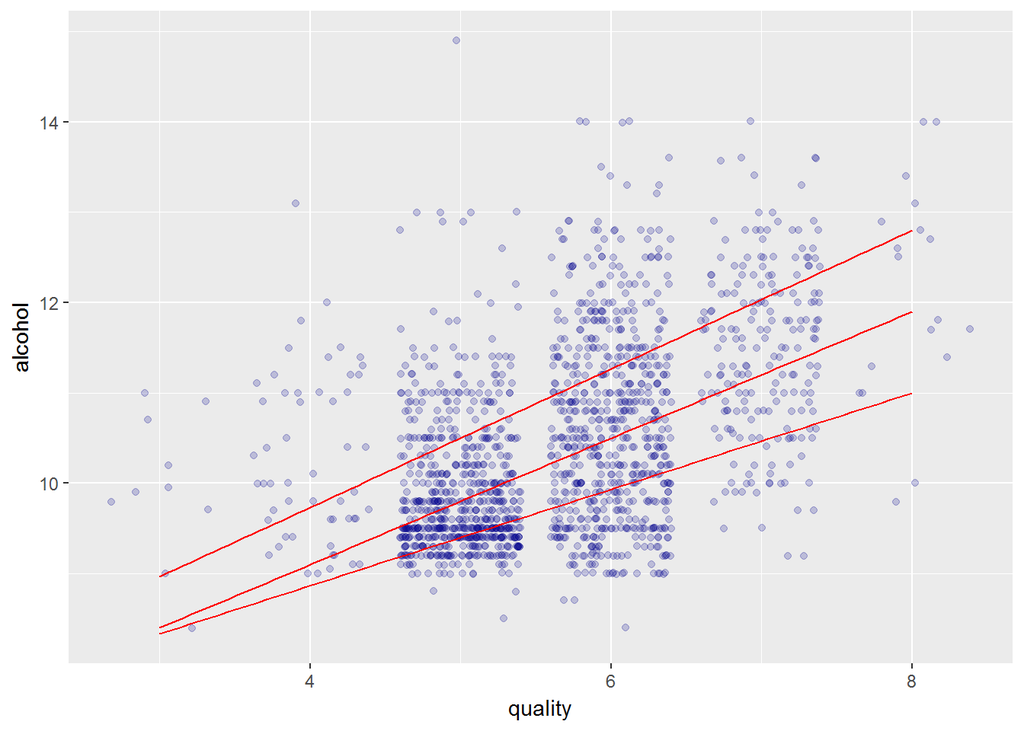

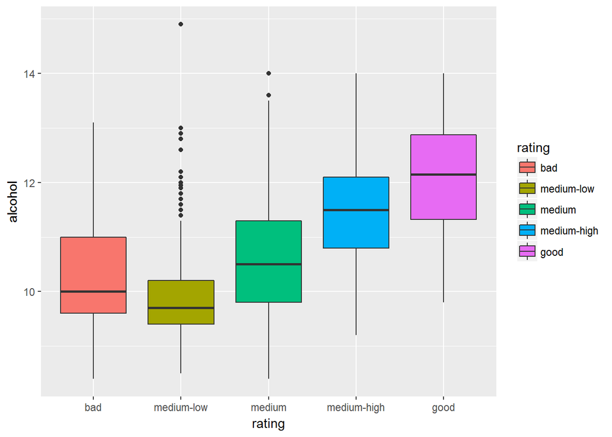

```
## df$rating: bad
##    Min. 1st Qu.  Median    Mean 3rd Qu.    Max.
##    8.40    9.60   10.00   10.22   11.00   13.10
## --------------------------------------------------------
## df$rating: medium-low
##    Min. 1st Qu.  Median    Mean 3rd Qu.    Max.
##   8.500   9.400   9.700   9.901  10.200  14.900
## --------------------------------------------------------
## df$rating: medium
##    Min. 1st Qu.  Median    Mean 3rd Qu.    Max.
##    8.40    9.80   10.50   10.63   11.30   14.00
## --------------------------------------------------------
## df$rating: medium-high
##    Min. 1st Qu.  Median    Mean 3rd Qu.    Max.
##    9.20   10.80   11.50   11.47   12.10   14.00
## --------------------------------------------------------
## df$rating: good
##    Min. 1st Qu.  Median    Mean 3rd Qu.    Max.
##    9.80   11.32   12.15   12.09   12.88   14.00
```

可以看到，酒精度和品质，在从bad到medium-low有下降，但是从medium-low开始，alcohol和rating有了明显的趋势。

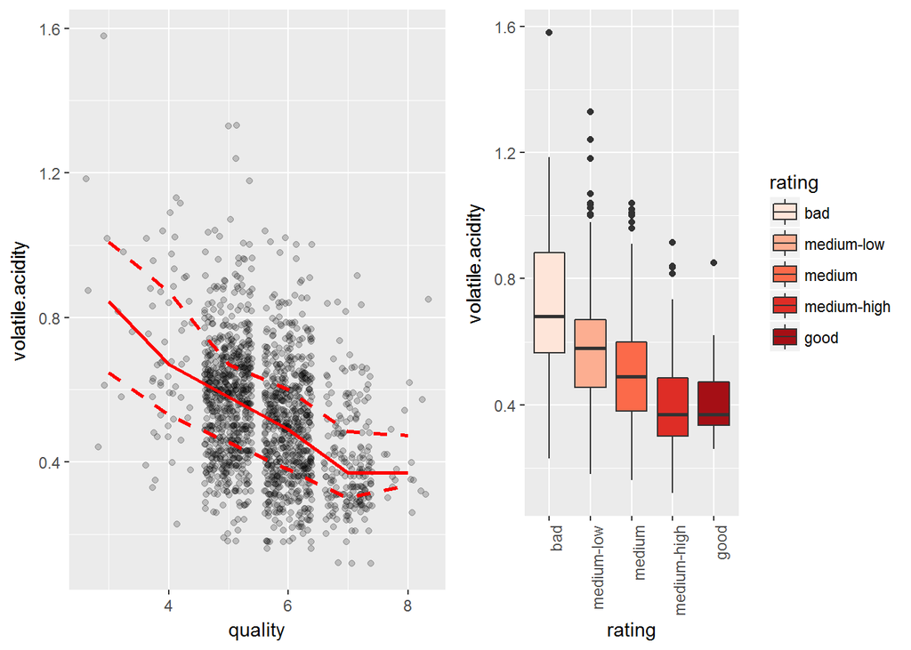

```
## df$rating: bad
##    Min. 1st Qu.  Median    Mean 3rd Qu.    Max.
##  0.2300  0.5650  0.6800  0.7242  0.8825  1.5800
## --------------------------------------------------------
## df$rating: medium-low
##    Min. 1st Qu.  Median    Mean 3rd Qu.    Max.
##  0.1800  0.4550  0.5800  0.5769  0.6700  1.3300
## --------------------------------------------------------
## df$rating: medium
##    Min. 1st Qu.  Median    Mean 3rd Qu.    Max.
##  0.1600  0.3800  0.4900  0.4975  0.6000  1.0400
## --------------------------------------------------------
## df$rating: medium-high
##    Min. 1st Qu.  Median    Mean 3rd Qu.    Max.
##  0.1200  0.3000  0.3700  0.4039  0.4850  0.9150
## --------------------------------------------------------
## df$rating: good
##    Min. 1st Qu.  Median    Mean 3rd Qu.    Max.
##  0.2600  0.3350  0.3700  0.4233  0.4725  0.8500
```

可以看到随着quality的提升， volatile acidity也随之下降，但是在medium-high和good区间，volatile acidity变化变缓，随之接近。

#### 5.3 Chlorides and Quality

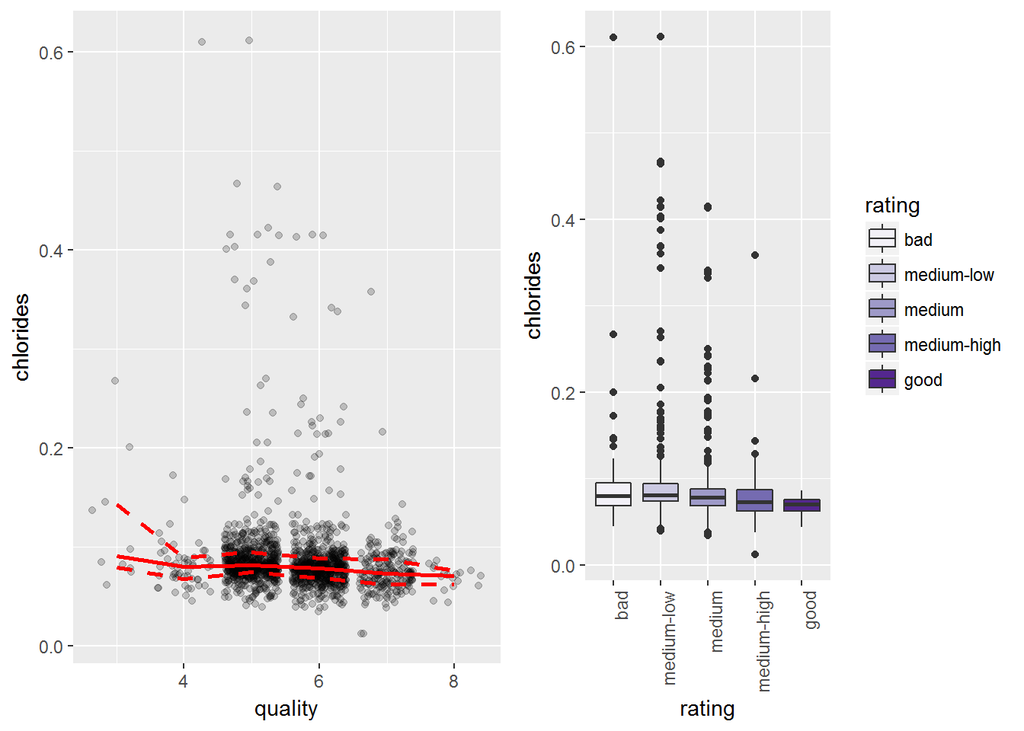

```
## df$rating: bad
##    Min. 1st Qu.  Median    Mean 3rd Qu.    Max.
## 0.04500 0.06850 0.08000 0.09573 0.09450 0.61000
## --------------------------------------------------------
## df$rating: medium-low
##    Min. 1st Qu.  Median    Mean 3rd Qu.    Max.
## 0.03900 0.07400 0.08100 0.09273 0.09400 0.61100
## --------------------------------------------------------
## df$rating: medium
##    Min. 1st Qu.  Median    Mean 3rd Qu.    Max.
## 0.03400 0.06825 0.07800 0.08496 0.08800 0.41500
## --------------------------------------------------------
## df$rating: medium-high
##    Min. 1st Qu.  Median    Mean 3rd Qu.    Max.
## 0.01200 0.06200 0.07300 0.07659 0.08700 0.35800
## --------------------------------------------------------
## df$rating: good
##    Min. 1st Qu.  Median    Mean 3rd Qu.    Max.
## 0.04400 0.06200 0.07050 0.06844 0.07550 0.08600
```

Chlorides和rating看起来只有微乎其微的关系，随着chlorides增加，红酒的品质有微弱下降趋势。

##### 5.4 其他因素与Quality的关系

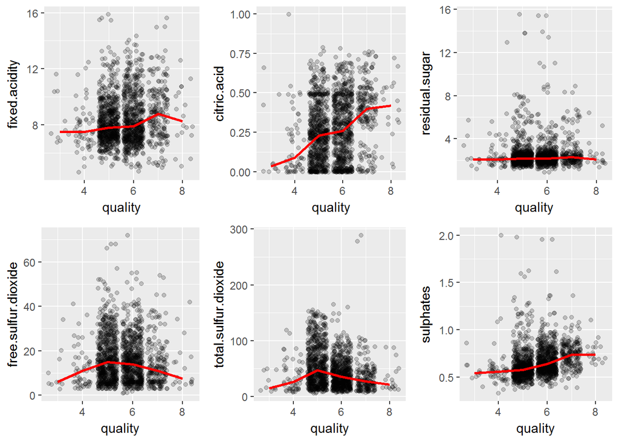

从这张集合图可以看到，大多数变量和quality没有特别明显的趋势。

#### 5.5 Density

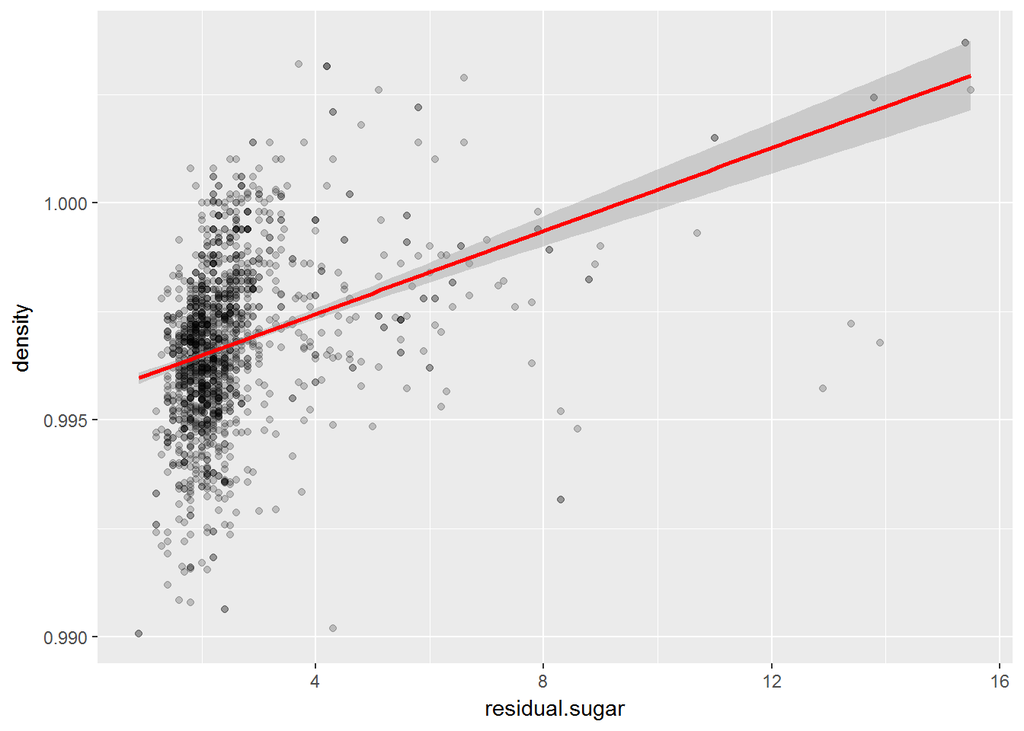

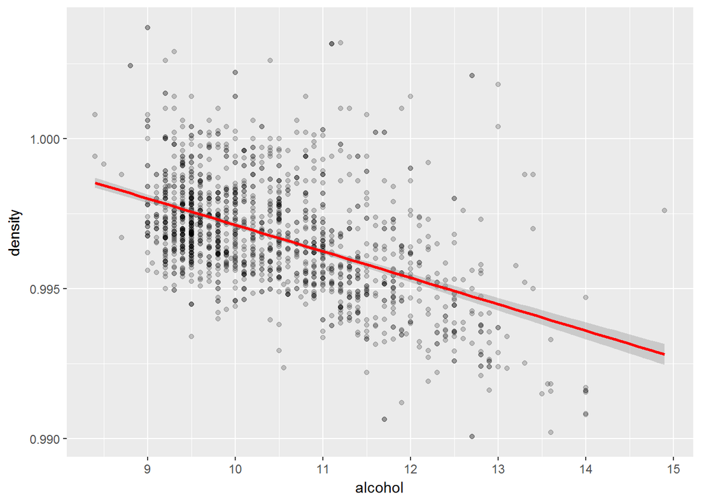

除了quality外，我们还对density特别感兴趣，从了解的红酒知识，density与很多要素有相关性，从上图可以看到density与residual sugar有一定线性相关性。Alcohol与density也有明显的线性相关性。

除了以上两个变量， fixed.acidity,citric.acid, 和chlorides 与 density 的相关性分别为0.66,0.36,0.20 ，还有total.sulfur.dioxide，free.sulfur.dioxide两个变量，作图观察。

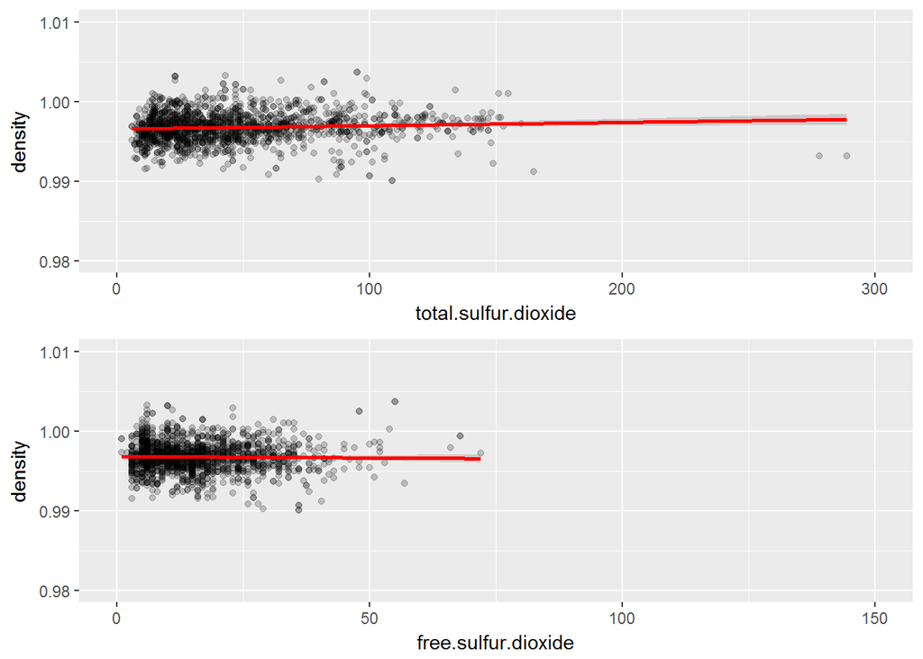

可以看到这两个因素，对于density来说没有太多相关性。

#### 5.6 其他因素之间

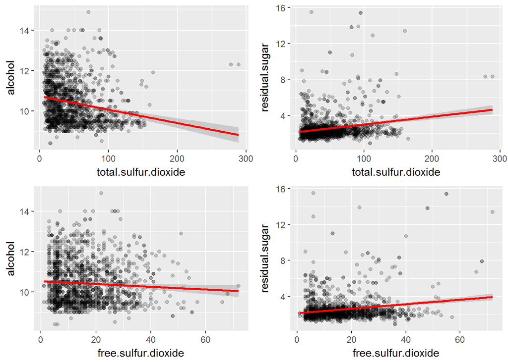

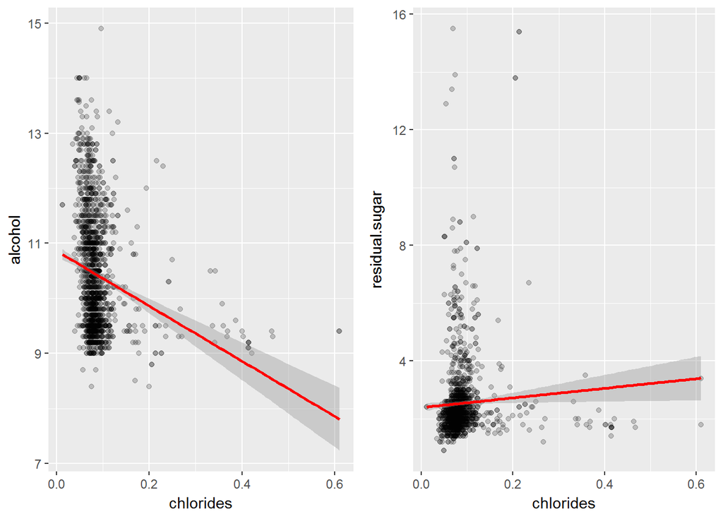

Chlorides与alcohol为负相关，但是与residual.sugar是正向影响的。

### 6.Bivariate Analysis

**Talk about some of the relationships you observed in this part of the investigation. How did the feature(s) of interest vary with other features in the dataset?**

在上面的图形分析上，可以看到，重点观察了quality与其他变量的关系，alochol是众多变量中对quality相关性较高，其趋势明显，促进quality提升。除此之外，还有volatile.acidity是相反的，对quality是负相关。其他的变量看起来都表现较弱。

**Did you observe any interesting relationships between the other features (not the main feature(s) of interest)?**

是的，可以看到density与total.sulfur.dioxide与free.sulfur.dioxide几乎没有任何相关性。total.sulfur.dioxide与free.sulfur.dioxide这样的化学元素是不会对密度这样的物理属性形成明显的直接关系。

**What was the strongest relationship you found?**

相关性最强的是density与residual_sugar，residual_sugar越多，density越大；还有alcohol，含量越少，density越大。

### 7. Multivariate Plots Section

多变量分析，单纯从一个因子看观察并不清晰，再次创造额外的两个分类变量来进一步观察。 我创造了关于酒精度的分类变量和PH值分类变量。

#### 7.1achl.label and pH.label

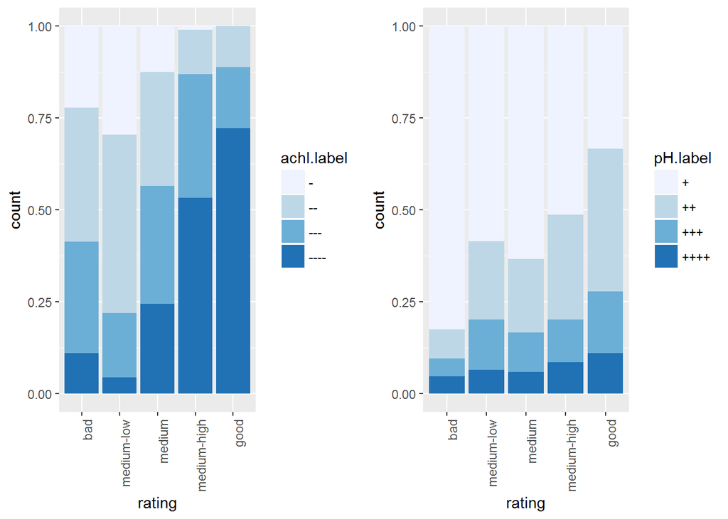

可以明显看出，随着酒精含量越来越高，红酒等级越来越高。而PH值变化并不明显。

#### 7.2 Alcohol, Volatile.acidity and Quality

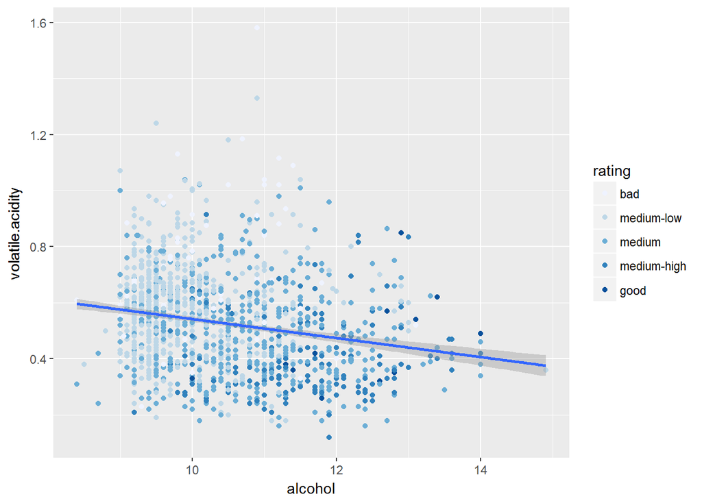

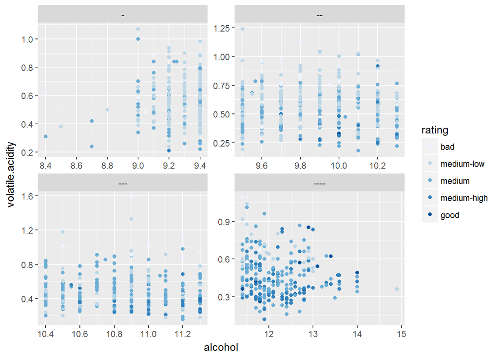

在x轴和y轴之间没有明显的关联。从颜色深度上观察，更好的红酒(深色圆点)明显在右下角，而更差的葡萄酒(较轻的点)则在左上方。这意味着随着酒精含量的增加和酸度的降低，葡萄酒的品质会更好。

### 7.3 Chlorides,Total.sulfur.dioxide and Quality

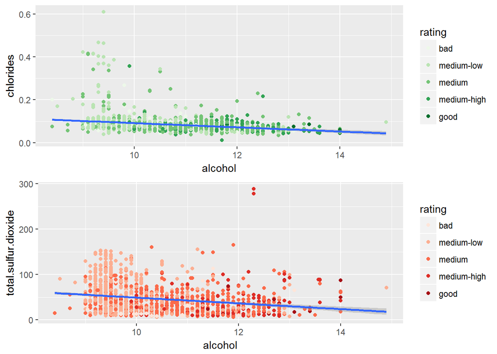

基于双变量分析(chlorides and total.sulfur.dioxide)同样地，在右下角的深色圆点看起来更多，可以表明更好的品质。

### 7.4 Sulphates 硫酸盐

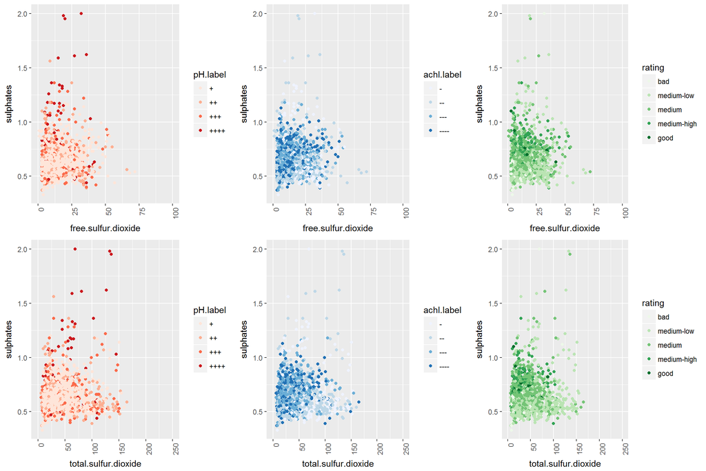

在整个数据集里我发现Sulphates几乎与其他变量没有相关。从数据集中的变量无法或者更多，从图形上也可以无法观察到特别明显的趋势。

### 8.模型建立

#### 8.1 建立训练集与验证集

挑选线性关系较强的变量入模，反复调整后，确定入模变量表现最强。

```
##
## Calls:
## m1: lm(formula = df$quality ~ df$volatile.acidity, data = df)
## m2: lm(formula = df$quality ~ df$volatile.acidity + df$chlorides,
##     data = df)
## m3: lm(formula = df$quality ~ df$volatile.acidity + df$chlorides +
##     df$total.sulfur.dioxide, data = df)
## m4: lm(formula = df$quality ~ df$volatile.acidity + df$chlorides +
##     df$total.sulfur.dioxide + df$pH, data = df)
## m5: lm(formula = df$quality ~ df$volatile.acidity + df$chlorides +
##     df$total.sulfur.dioxide + df$pH + df$citric.acid, data = df)
## m6: lm(formula = df$quality ~ df$volatile.acidity + df$chlorides +
##     df$total.sulfur.dioxide + df$pH + df$citric.acid + df$alcohol,
##     data = df)
##
## =============================================================================================
##                               m1         m2         m3         m4         m5         m6
## ---------------------------------------------------------------------------------------------
##   (Intercept)               6.565***   6.708***   6.845***   6.981***   6.219***   5.025***
##                            (0.058)    (0.065)    (0.068)    (0.425)    (0.510)    (0.469)
##   df$volatile.acidity      -1.760***  -1.731***  -1.681***  -1.671***  -1.490***  -1.291***
##                            (0.104)    (0.104)    (0.102)    (0.106)    (0.126)    (0.115)
##   df$chlorides                        -1.807***  -1.696***  -1.733***  -1.918***  -0.654
##                                       (0.394)    (0.389)    (0.406)    (0.411)    (0.380)
##   df$total.sulfur.dioxide                        -0.004***  -0.004***  -0.004***  -0.002***
##                                                  (0.001)    (0.001)    (0.001)    (0.001)
##   df$pH                                                     -0.042      0.137     -0.551***
##                                                             (0.127)    (0.144)    (0.136)
##   df$citric.acid                                                        0.356**   -0.102
##                                                                        (0.133)    (0.123)
##   df$alcohol                                                                       0.316***
##                                                                                   (0.017)
## ---------------------------------------------------------------------------------------------
##   R-squared                     0.2        0.2        0.2        0.2        0.2        0.3
##   adj. R-squared                0.2        0.2        0.2        0.2        0.2        0.3
##   sigma                         0.7        0.7        0.7        0.7        0.7        0.7
##   F                           286.5      155.6      121.4       91.0       74.5      130.9
##   p                             0.0        0.0        0.0        0.0        0.0        0.0
##   Log-likelihood            -1792.7    -1782.2    -1760.2    -1760.1    -1756.5    -1604.0
##   Deviance                    882.8      871.3      847.6      847.5      843.7      697.0
##   AIC                        3591.4     3572.4     3530.4     3532.3     3527.1     3224.0
##   BIC                        3607.5     3593.9     3557.3     3564.5     3564.7     3267.0
##   N                          1597       1597       1597       1597       1597       1597
## =============================================================================================
```

#### 3.2 模型诊断

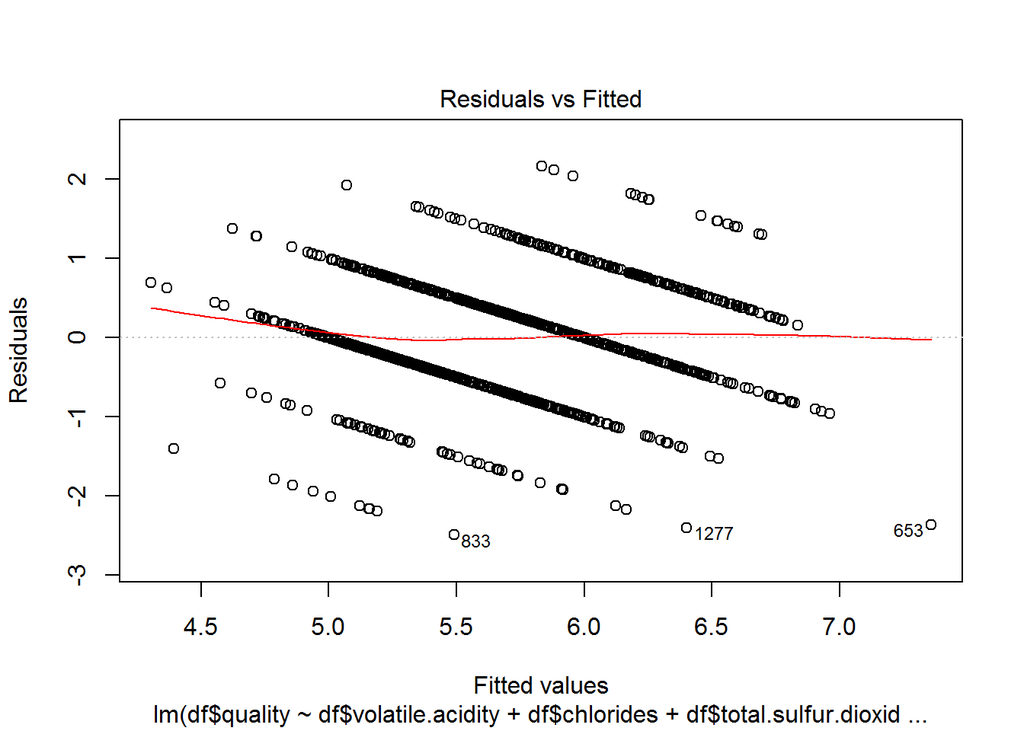

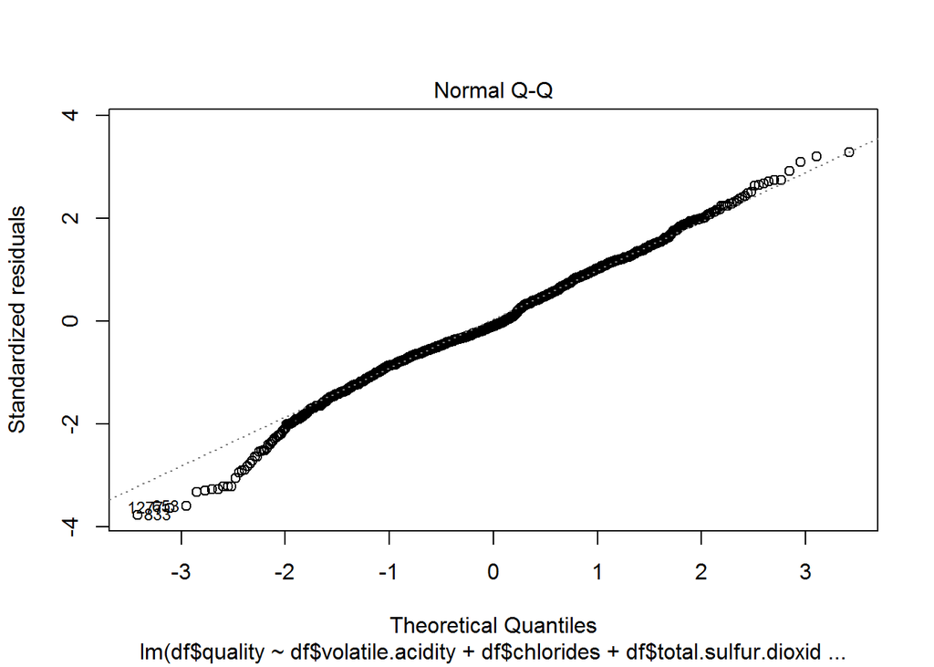

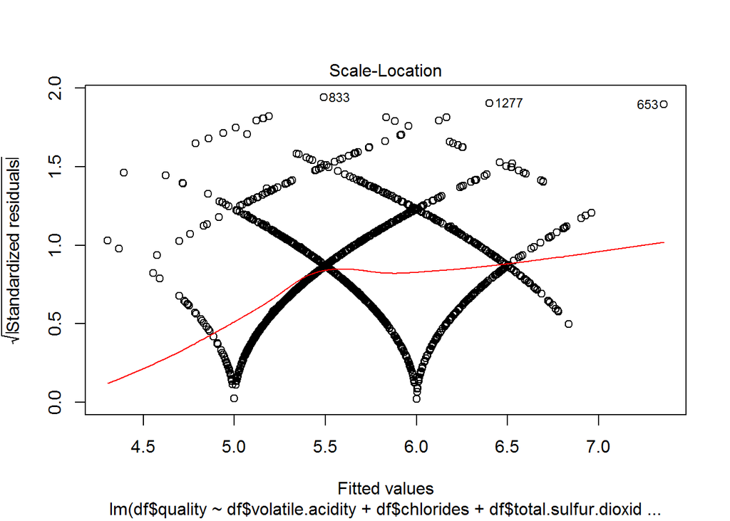

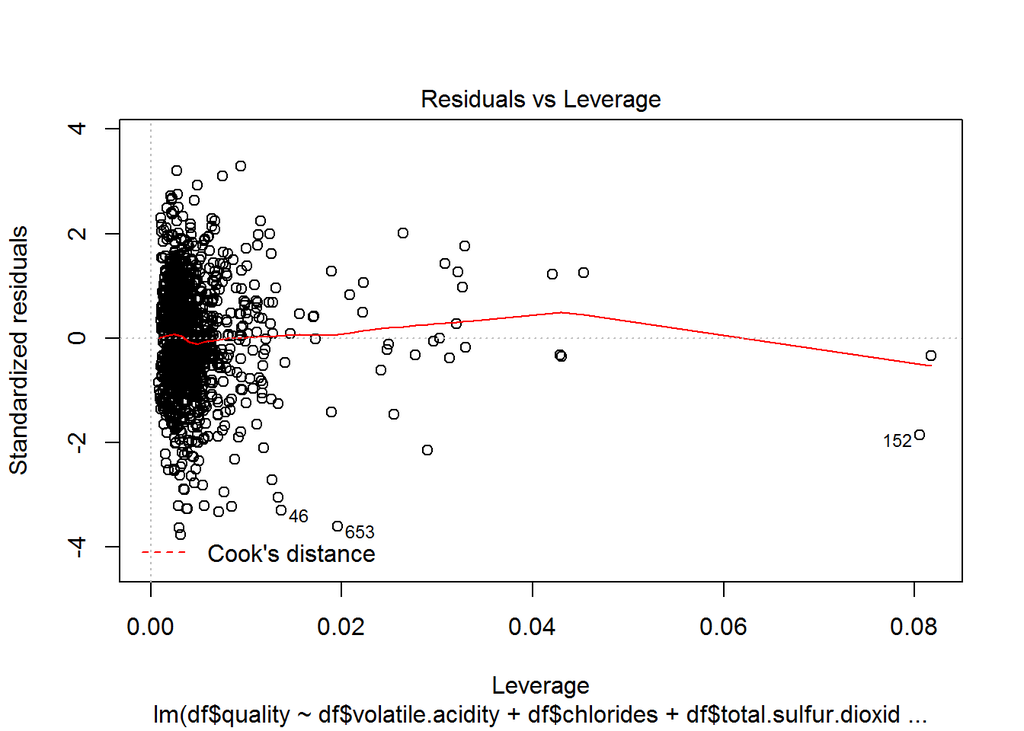

#### 8.3 模型验证

通过成分残差图即偏残差图，判断因变量与自变量之间是否呈非线性关系 从生成的图像来说，因变量和各个自变量的线性关系并不是很明显，模型效果一般。

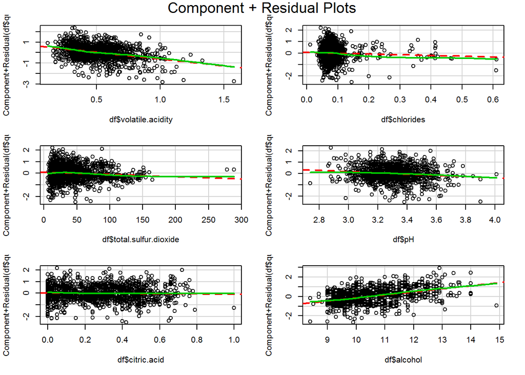

### 9. Multivariate Analysis

**Talk about some of the relationships you observed in this part of the investigation. Were there features that strengthened each other in terms of looking at your feature(s) of interest?** 我发现alcohol酒精和volatile.acidity这两个变量最可能独立影响葡萄酒的质量。

**Were there any interesting or surprising interactions between features?** 是的，除了前面讨论的密度，alcohol，我还发现 citric.acid与红酒品质的关系，但是数据量小，且并不全面，导致我无法得出结论。

**OPTIONAL: Did you create any models with your dataset? Discuss the strengths and limitations of your model.** 是的，效果并不是很好，主要还是数据量小，影响红酒品质，并不仅仅是这些变量就可以起到决定性作用。

### Plot One

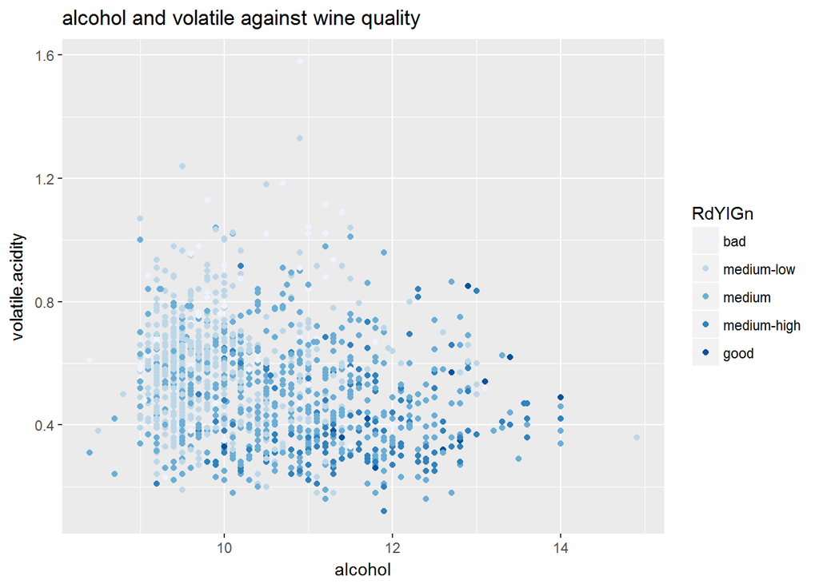

首先,可以看到 volatile.acidity 和 alcohol 是独立的. 其次，不同品质的红酒的分布是不同的，特别是最差的红酒在左上边，而最好的右下边。 可以看出随着volatile.acidity上升，酒品质下降。而随着酒精含量上升，酒品质上升。

### Plot Two

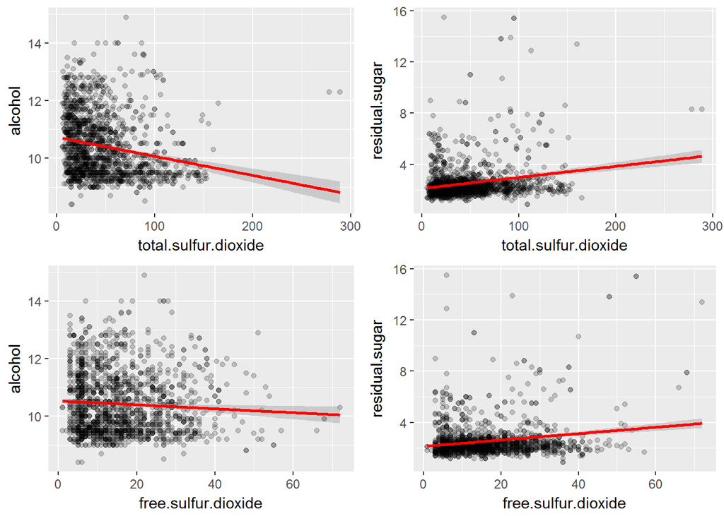

可以看到total.sulfur.dioxide与alcohol/residual.sugar 之间有意向不到的线性关系

### Plot Three

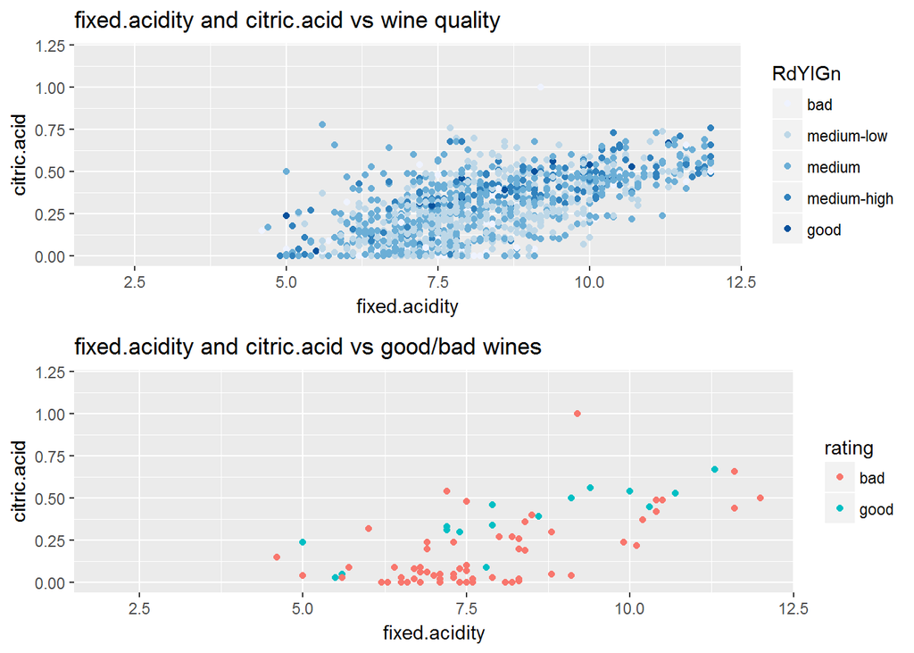

比较fixed.acidity和citric.acid的关系，随着citric.acid提高，对红酒品质略微提升，而fixed.acidity的变化，好坏区分度并不好。样本数据量还是太少，无法明显的看出来我预期想要的。

### 10.反思

```
前面也提过本数据集，变量只是红酒主要的基本成分，并没有微量成分，由葡萄酒的品尝原理我们知道，葡萄酒中的微量成分是香气和滋味成分中最主要的部分，这些成分数目极大而浓度极小。这可能对我们的分析会造成不利的影响，即体现红酒质量的自变量缺失了，某些甚至可能是重要的变量。
而且在数据量上，由于本数据样本较小，且红酒品质多数集中5，6级的评级，且分布较为平均，不是能很好的分析出影响一瓶好红酒有哪些因素。
其次建模方法上，我先观察了变量之间的线性关系，挑选了线性关系较强的变量，从多元线性建立模型，反复调整后，最终选择了表现最强的变量入模。
经过模型验证，说明模型效果一般。

但是模型效果的好坏的决定因素是变量，变量的有效性，数据量都先天决定了模型的效果，和将来的实际应用。今后应该进一步去收集很多的变量及数据量，将对模型的建立有良好的促进效果。
```